# Utah Basic Esthetics Integrated Competency Assessment CIB

State of Utah Candidate Information Bulletin (CIB)

Effective: January 01, 2026

# Frequently Asked Questions

## 1. How do I register to test?

To register and schedule for testing, go to: https://www.provexam.com/register

You may also call or text us at (801) 733-4455. More information about registering is provided in the Registration section below.

## 2. Where can I test?

You may test at any one of Prov’s testing centers. Locations are provided in the Testing Site Locations section below.

## 3. How much does it cost?

The Utah Basic Esthetics Integrated Competency Assessment (ICA) costs $105 for the assessment.

## 4. When do I get my test results?

You will receive your unofficial assessment results by email within minutes of completing your exam. All official results will be sent to the State within 3 days following the assessment.

## 5. What is on the test?

Assessment information is provided in the Assessment Descriptions section of this bulletin.

# More Questions

Please read through this bulletin completely for answers to your questions. If you still have unanswered questions, you may contact us at the following:

### For Testing Questions

**Prov, Inc.**

200 W Civic Center Blvd, Suite 160  
Sandy, Utah 84070  
Phone: (877) 228-3926  
Call or Text: (801) 733-4455 (Messaging rates may apply)  
Website: www.provexam.com  
Email: support@provexam.com  
Hours: 6:00 AM to 10:00 PM MT, Monday - Friday

### For Licensing Questions

**Utah Department of Commerce | Division of Professional Licensing (DOPL)**

160 E 300 S, 4th Floor  
Salt Lake City, UT 84114  
Phone: (801) 530-6628  
Toll-free in UT: (866) 275-3675  
Website: https://dopl.utah.gov/cosmo/index.html  
Hours: 8:00 AM to 5:00 PM MT

# General Testing Information

The Utah Division of Professional Licensing (DOPL) has contracted with Prov, Inc. to administer the Utah Basic Esthetics Integrated Competency Assessment (ICA).

The purpose of this bulletin is to provide you with information about taking your permit assessment with the State of Utah.

Prov is not authorized to make the determination of which assessment candidates must take. If a candidate is unsure which assessment is needed for their profession, the candidate must resolve this question prior to scheduling. If candidates have questions regarding which exam(s) to take, please check with your school, or review the information found on the [DOPL website](https://dopl.utah.gov/cosmo/index.html).

## Examination Categories and Cost

Candidates seeking a Permit in the State of Utah must successfully complete the Integrated Competency Assessment. This single assessment evaluates both knowledge and applied skill, which are intertwined throughout the testing process.

The total cost for the assessment is **$105** per attempt, whether you are testing for the first time or if you are retaking the examination.

# How to Register and Schedule

## Testing with Prov

Your Integrated Competency Assessment (ICA) will be administered by computer at one of Prov’s testing centers but includes a physical demonstration of skills as part of the assessment. Prov’s testing system is easy to use and requires no specific computer experience to complete the assessment.

Watch a demonstration video of [Prov’s testing system](https://youtu.be/h3T9svnIdLY)

## Prior to Registration

All candidates **must** create a UtahID before registering for their examination. The same email address must be used when:

- Creating the [UtahID](https://dts.utah.gov/idhelp/account-creation/) account
- Registering for the examination with Prov
- Submitting the permit application with the Division of Professional Licensing (DOPL)

Using different email addresses will prevent examination scores from linking to the candidate’s UtahID account and application record. This will cause delays in processing the permit application.

Candidates are strongly encouraged to use a personal email address when creating their UtahID account. Do not use a work or school email address, as this email will remain the primary point of contact with the Division throughout your career, including permit renewal notices and other important communications.

Please see “Proof of Identity” section for more information on acceptable forms of ID.

## Where to Take Your Exam in Utah

Prov has established *four (4)* testing centers in Utah where you may take your Utah Permit ICA. Locations are provided in the Testing Site Locations section below.

## Online Registration Steps

1. Go to https://provexam.com/ or call the Prov Call Center to complete the registration process if preferred.
2. Click “Schedule a Test”
3. Click “Self Registration” under “Self Registration”

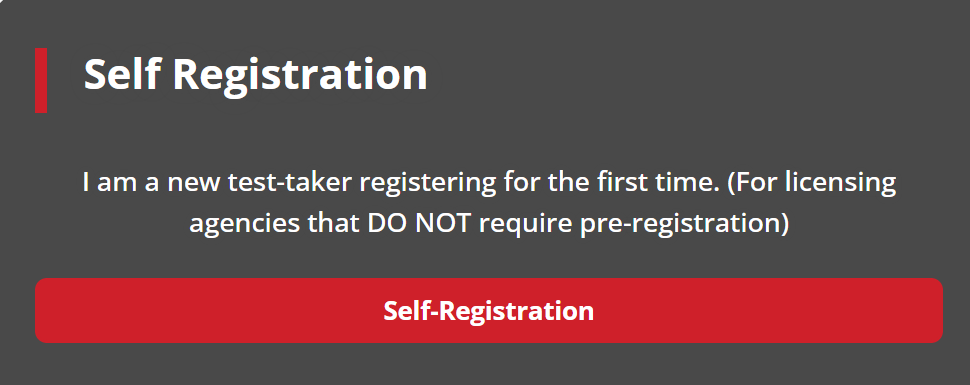

4. Use the Dropdown menu under “Select Certifying Body”, and select: **UT Cosmetology**
5. Under “Select a License/certificate”, choose Utah Basic Esthetics ICA, then press “Next”
6. Experience Requirement: Select “Yes” if you are qualified for this test
7. Select the school you attended, scroll to the bottom of the page and click “Submit”
8. Enter your information exactly as it appears on your government issued ID into the fields that are provided.
- Name (First, Middle and Last)
- Street address
- City, State, Postal Code

Additionally, please provide the following:

- Social Security number
  - **Using a social security number that is not yours is federal fraud**
- Email Address (same as used to create your Utah ID)
- Telephone Number
- Birthdate

Then select the button labeled “SAVE CHANGES”

## Scheduling Your Exam Online

1. Select a Date, Time, and Location for your assessment by selecting the link labeled “Find a suitable time and venue”
2. Select a convenient test site by scrolling down to see all available test sites. Prov’s scheduling system will search for the closest testing centers to the address you entered. Select the SCHEDULE hyperlink to check the calendar for a specific testing center.
3. Select a date and time from the calendar
4. If you want to schedule a second assessment, select the “Schedule Another Test” button
5. Proceed to payment with electronic payment or coupon code, if provided by your school

If you have any problems with online scheduling, you may call or text Prov at (801) 733-4455.

## Scheduling by Phone

To schedule an assessment by phone, you may call or text Prov at (801) 733-4455 or send an email to support@provexam.com.

Prov scheduling staff is available 6:00 AM through 10:00 PM MT, Monday through Friday.

Candidates should be prepared to provide the Prov scheduling staff with their full name (first, middle, last), social security number and their address. Once registered in the database, Prov staff will search for the next available testing date and time. Once candidates are scheduled, Prov staff will email them information regarding their assessment schedule.

# Policies

## Cancel/Rescheduling Policy

You can reschedule or cancel your testing appointment online for free if you do so at least **three (3) days** before your ICA date. If you miss your appointment or fail to reschedule or cancel by these deadlines, you will forfeit your exam fee.

## Emergency Situation Policy

If you are unable to attend your scheduled assessment due to an emergency, you must provide written documentation to Prov for review.

You may call or text Prov at (801) 733-4455 or send an email to support@provexam.com.

If approved, you will be notified and provided with authorization to reschedule your assessment.

# Preparing for Your Exams

The Cosmetology and Associated Professions’ exams utilized in Utah are designed to test what you should know and can demonstrate in your specific Cosmetology/Barbering and related fields industries.

## Kit and Supply Information

Candidates must bring all needed supplies and cannot borrow anything during the ICA. Suggested supplies are included in this Candidate Information Bulletin (CIB).

- **Barbers and Cosmetologists:** Mannequin heads MUST be a full-size head; “minikin” or “junior” mannequin heads are NOT permitted.
- **Cosmetologists:** Thermal curling is demonstrated with a cold thermal curling iron.
- **Electrologist:** A live model is required for the ICA. The model must be 18 years of age or older and present a government issued photo ID at the time of check-in.
- Kits must be no larger than 30 inches by 30 inches. Kits, bags etc. must fit completely under the candidate’s work area.
- Tripods may be used but must be within the candidate’s immediate work area (close to or up against workstation).
- Disinfectants must be disinfecting wipes; sanitizers and all other products must be non-aerosol.

## Mannequin Information

**Please Note:** All assessments are performed using **Mannequins**, except where noted. Live models will not be accepted. You are required to bring all necessary materials for your assessment.

Mannequin heads MUST be a full-size head, “minikin” or “junior” mannequin heads are NOT permitted.

# Exam Description

The Utah Basic Esthetics ICA combines knowledge and hands-on competency in a single integrated assessment. The following is an outline of the content areas covered and the approximate target representation of these areas on the exam.

| Content Area | Percent of Exam |
| --- | --- |
| Professional ethics | 1 |
| Implements, tools, and equipment for basic esthetics | 2 |
| Analysis of the hair and skin | 6 |
| Diseases and disorders of the hair and skin, and prevention | 19 |
| Personal, client, and shop safety | 15 |
| Hair removal | 28 |
| Large area waxing | 5 |
| Extractions | 5 |
| Facials | 18 |
| Law and rule | 1 |

1. PRE-SERVICE MULTIPLE CHOICE INSTRUCTIONS (12 minutes)
2. BASIC ESTHETICS SERVICES PREPARATION (15 minutes)
3. BASIC FACIAL WITH MANUAL EXTRACTIONS (12 minutes plus individually examined portion)
4. BASIC FACIAL SERVICES MULTIPLE CHOICE INSTRUCTIONS (12 minutes)
5. NEW CLIENT PREPARATION FOR HAIR REMOVAL SERVICES (10 minutes)
6. EYEBROW WAX WITH SOFT WAX (2 minutes plus individually examined portion)
7. UPPER LIP WAX WITH HARD WAX (2 minutes plus individually examined portion)
8. WORK AREA CLEANUP (10 minutes)
9. HAIR REMOVAL AND WORK AREA CLEANUP MULTIPLE CHOICE INSTRUCTIONS (12 minutes)
10. BLOOD EXPOSURE PROCEDURE (5 minutes)
11. OTHER SERVICES AND PROCEDURES MULTIPLE CHOICE INSTRUCTIONS (12 minutes)

### Domain Details

The following outlines the scope of content covered by the Utah Basic Esthetics Assessment.

**Proctor–Verbal Instructions: Read to all candidates:** *“Please go to your assigned station and do nothing until instructed by the Proctor.”*

#### 1. PRE-SERVICE MULTIPLE CHOICE INSTRUCTIONS (12 minutes)

**Instructions:**

“*We will begin the Pre-Service Multiple Choice portion.*

*Please answer Questions 1-12 on your tablet.*

*Do not answer any further questions.*

*If you finish before the time goes off, do not close the browser and do not end the exam.*

*Please place the tablet on the front corner of the work station, remain quiet, and wait for the next instructions.*

*Ill repeat the instructions.*

*12 minutes for the multiple choice portion starts now.*

*Please begin.*”

**[All candidates finish before timer goes off.] Instructions:**

“*All candidates have finished; we will proceed.*”

**[Timer goes off before all candidates have finished.] Instructions:**

“*The time has ended; we will proceed.*”

#### 2. BASIC ESTHETICS SERVICES PREPARATION (15 minutes)

**Instructions:**

“*Plug in your wax pot now.*”

**Instructions:**

“*We will begin the Esthetics Services Preparation section.*

*The Skills portion is 15 minutes with a warning when 5 minutes remain.*

*Please prepare your work area, set up general supplies, and prepare your client for a basic facial and extractions.*

*You should also set up the supplies that are needed to demonstrate:*

*- cleansing the face,*

*- manual exfoliation,*

*- steaming the face with a towel,*

*- facial massage using effleurage and petrissage manipulations,*

*- face mask, and*

*- manual extractions using a comedone extractor.*

*Drape the client for facial services.*

*Ill repeat the instructions.*

*15 minutes for work area preparation, supplies set up, and client preparation starts now.*

*Please begin.*”

- **You will be examined on the following skills and actions:**
- **1. Disinfects all work areas completely excluding the iPad device**
- **2. Wears glove(s) on hand using disinfectant wipe**
- **3. Uses disinfectant in original manufacturer’s container with orginal label in English**
- **4. Disinfectant label must indicate EPA-registered, bactericidal, fungicidal, and virucidal**
- **5. Products labeled by the candidate must be in only English**
- **6. Uses hand sanitizer that has the manufacturer’s label in English**
- **7. Drapes client for facial services using correct combination of appropriate barrier(s) and drape type**
- **8. Resolves spills or tripping hazards on the floor immediately**
- **9. Follows infection control procedures**
- **10. Uses correct, labeled containers for ‘items to be disinfected’, ‘soiled linens’, and ‘trash’**

**[All candidates finish before timer goes off.] Instructions:**

“*All candidates have finished; we will proceed.*”

**[Timer goes off before all candidates have finished.] Instructions:**

“*The time has ended; we will proceed.*”

#### 3. BASIC FACIAL WITH MANUAL EXTRACTIONS (12 minutes plus individually examined portion)

**Instructions:**

“*We will begin the Basic Facial with Extractions service.*

*The Skills portion has variable timing.*

*This portion will be examined in 3 parts.*

*Part 1, demonstrate cleansing the face.*

*The cleansing part is 2 minutes.*

*Part 2, demonstrate a basic facial.*

*The basic facial part is 10 minutes with a warning when 2 minutes remain.*

*Part 3, demonstrate manual extractions.*

*The extractions part will be individually examined.*

*Do not demonstrate extractions until instructed to do so.*

*Ill repeat the instructions.*

*2 minutes for cleansing the face starts now.*

*Please begin.*”

- **You will be examined on the following skills and actions:**
- **1. Implements are visibly clean**
- **2. Wears gloves when applying any products**
- **3. Cleanses eye and lip areas**
- **4. Cleanses entire face**

**[All candidates finish before timer goes off.] Instructions:**

“*All candidates have finished; we will proceed.*”

**[Timer goes off before all candidates have finished.] Instructions:**

“*The time has ended; we will proceed.*”

**Instructions:**

“*Please demonstrate the Basic Facial which includes*

*- manual exfoliation,*

*- steaming the face with a towel,*

*- facial massage using effleurage and petrissage manipulations, and*

*- applying a face mask.*

*Ill repeat the instructions.*

*10 minutes for the basic facial starts now.*

*Please begin.*”

- **You will be examined on the following skills and actions:**
- **5. Performs manual exfoliation**
- **6. Wrings steam towel to prevent water dripping onto client**
- **7. Tests temperature of steam towel on correct location**
- **8. Applies a steam towel leaving nose and mouth exposed**
- **9. Removes steam towel**
- **10. Removes all residue of product**
- **11. Performs facial massage using effleurage manipulation using multiple soft, continuous stroking movements with fingers**
- **12. Performs facial massage using petrissage manipulation**
- **13. Removes massage product completely**
- **14. Applies facial mask to entire face**
- **15. Removes facial mask product completely**
- **16. Applies moisturizer or sunscreen to entire face**
- **17. Does not allow product(s) to remain in eyes, nose, or mouth**

**[All candidates finish before timer goes off.] Instructions:**

“*All candidates have finished; please wait for the examiners instructions.*”

**[Timer goes off before all candidates have finished.] Instructions:**

“*The time has ended; please wait for the examiners instructions.*”

**Examiner Instructions:**

“*Demonstrate 2 manual extractions on the right cheek and conclude the service.*”

- **You will be examined on the following skills and actions:**
- **18. Applies simulated serum to area to be treated and excluding mouth, eyes, and/or nose**
- **19. Applies simulated desincrustation solution to area to be treated**
- **20. Wears gloves when performing manual extractions**
- **21. Braces when performing manual extractions**
- **22. Performs manual extractions with a comedone extractor on the cheek**
- **23. Applies toner or astringent to treated area**
- **24. Maintains correct draping throughout section**
- **25. Resolves spills or tripping hazards on the floor immediately**
- **26. Follows infection control procedures**
- **27. Uses correct, labeled containers for ‘items to be disinfected’, ‘soiled linens’, and ‘trash’**

**Examiner Instructions:**

“*Step back and wait for the next instructions.*”

**Instructions:**

“*All examiners have completed their evaluation; we will proceed.*”

#### 4. BASIC FACIAL SERVICES MULTIPLE CHOICE INSTRUCTIONS (12 minutes)

**Instructions:**

“*We will begin the Basic Facial Services Multiple Choice portion.*

*Please answer Questions 13-24 on your tablet.*

*Do not answer any further questions.*

*If you finish before the time goes off, do not close the browser and do not end the exam.*

*Please place the tablet on the front corner of the work station, remain quiet, and wait for the next instructions.*

*Ill repeat the instructions.*

*12 minutes for the multiple choice portion starts now.*

*Please begin.*”

**[All candidates finish before timer goes off.] Instructions:**

“*All candidates have finished; we will proceed.*”

**[Timer goes off before all candidates have finished.] Instructions:**

“*The time has ended; we will proceed.*”

#### 5. NEW CLIENT PREPARATION FOR HAIR REMOVAL SERVICES (10 minutes)

**Instructions:**

“*We will begin the NEW Client Preparation for the Hair Removal service.*

*The Skills portion is 10 minutes with a warning when 2 minutes remain.*

*Please break down your work area from the previous client.*

*Set up your work area and prepare a new client for hair removal services.*

*You should set up the supplies that are needed to demonstrate:*

*- simulated soft wax removal on the eyebrow, and*

*- hard wax removal on the upper lip.*

*Drape the client for hair removal services.*

*Ill repeat the instructions.*

*10 minutes for work area preparation, supplies set up, and client preparation starts now.*

*Please begin.*”

- **You will be examined on the following skills and actions:**
- **1. Disinfects all work areas completely excluding the iPad device**
- **2. Wears glove(s) on hand using disinfectant wipe**
- **3. Uses disinfectant in original manufacturer’s container with orginal label in English**
- **4. Disinfectant label must indicate EPA-registered, bactericidal, fungicidal, and virucidal**
- **5. Products labeled by the candidate must be in only English**
- **6. Uses hand sanitizer that has the manufacturer’s label in English**
- **7. Drapes client for hair removal services using correct combination of appropriate barrier(s) and drape type**
- **8. Resolves spills or tripping hazards on the floor immediately**
- **9. Follows infection control procedures**
- **10. Uses correct, labeled containers for ‘items to be disinfected’, ‘soiled linens’, and ‘trash’**

**[All candidates finish before timer goes off.] Instructions:**

“*All candidates have finished; we will proceed.*”

**[Timer goes off before all candidates have finished.] Instructions:**

“*The time has ended; we will proceed.*”

#### 6. EYEBROW WAX WITH SOFT WAX (2 minutes plus individually examined portion)

**Instructions:**

“*We will begin the Soft Wax service.*

*The Skills portion has variable timing.*

*This portion will be examined in 2 parts.*

*Part 1, demonstrate preparation of the client for soft wax removal.*

*The client preparation part is 2 minutes.*

*Part 2, demonstrate soft wax application and removal on the eyebrow.*

*Use simulated product for soft wax.*

*The application and removal part will be individually examined.*

*Do not demonstrate soft wax application or removal until instructed to do so.*

*Ill repeat the instructions.*

*2 minutes for client preparation starts now.*

*Please begin.*”

- **You will be examined on the following skills and actions:**
- **1. Implements are visibly clean**
- **2. Wears gloves when applying any product**
- **3. Applies simulated pre-epilation product to area to be treated before applying wax**
- **4. Dries excess moisture**
- **5. Tests temperature of the simulated wax product on correct area**

**[All candidates finish before timer goes off.] Instructions:**

“*All candidates have finished; please wait for the examiners instructions.*”

**[Timer goes off before all candidates have finished.] Instructions:**

“*The time has ended; please wait for the examiners instructions.*”

**Examiner Instructions:**

“*Demonstrate the application and removal of soft wax from the eyebrow.*

*Perform this section on the entire edge of one eyebrow.*”

- **You will be examined on the following skills and actions:**
- **6. Simulated soft wax application starts at the inside of brow**
- **7. Applies soft wax in direction of hair growth**
- **8. Braces when applying wax**
- **9. Applicator is held at 45 degree angle, not flat or vertical to the eyebrow**
- **10. Soft wax is applied to entire edge of brow**
- **11. Applies removal strip to entire edge of brow**
- **12. Smooths removal strip in direction of hair growth**
- **13. Removes strip in direction opposite of hair growth**
- **14. Removes wax strip parallel to skin at an angle less than 45 degrees**
- **15. Applies simulated post-epilation product to treated area**
- **16. Maintains correct draping throughout section**
- **17. Resolves spills or tripping hazards on the floor immediately**
- **18. Follows infection control procedures**
- **19. Uses correct, labeled containers for ‘items to be disinfected’, ‘soiled linens’, and ‘trash’**

**Examiner Instructions:**

“*Step back and wait for the next instructions.*”

**Instructions:**

“*All examiners have completed their evaluation; we will proceed.*”

#### 7. UPPER LIP WAX WITH HARD WAX (2 minutes plus individually examined portion)

**Instructions:**

“*We will begin the Hard Wax service.*

*The Skills portion has variable timing.*

*This portion will be examined in 2 parts.*

*Part 1, demonstrate preparation of the client for hard wax removal.*

*The client preparation part is 2 minutes.*

*Part 2, demonstrate hard wax application and removal on one side of the upper lip.*

*The application and removal part will be individually examined.*

*Do not demonstrate hard wax application or removal until instructed to do so.*

*Ill repeat the instructions.*

*2 minutes for client preparation starts now.*

*Please begin.*”

- **You will be examined on the following skills and actions:**
- **1. Implements are visibly clean**
- **2. Wears gloves when applying any product**
- **3. Applies simulated pre-epilation product to area to be treated before applying wax**
- **4. Dries excess moisture**
- **5. Tests temperature of the wax on correct area**

**[All candidates finish before timer goes off.] Instructions:**

“*All candidates have finished; please wait for the examiners instructions.*”

**[Timer goes off before all candidates have finished.] Instructions:**

“*The time has ended; please wait for the examiners instructions.*”

**Examiner Instructions:**

“*Demonstrate the application and removal of hard wax from one side of the upper lip.*”

- **You will be examined on the following skills and actions:**
- **6. Applies hard wax to one half of the upper lip**
- **7. Braces when applying wax**
- **8. Applicator is held at 45 degree angle, not flat or vertical to the lip**
- **9. Smooths wax**
- **10. Leaves thick tab of wax at the edge to be used for removal**
- **11. Tests that wax has hardened by hand or applicator**
- **12. Does not scratch or pick at wax to remove it**
- **13. Holds skin taut**
- **14. Removes wax in one continuous, quick motion**
- **15. Removes wax parallel to skin**
- **16. Removes wax completely**
- **17. Applies pressure after removing wax**
- **18. Applies simulated post-epilation product to treated area**
- **19. Maintains correct draping throughout section**
- **20. Resolves spills or tripping hazards on the floor immediately**
- **21. Follows infection control procedures**
- **22. Uses correct, labeled containers for ‘items to be disinfected’, ‘soiled linens’, and ‘trash’**

**Examiner Instructions:**

“*Step back and wait for the next instructions.*”

**Instructions:**

“*All examiners have completed their evaluation; we will proceed.*”

#### 8. WORK AREA CLEANUP (10 minutes)

**Instructions:**

“*We will begin the Work Area Cleanup for Hair Removal Services.*

*The Skills portion is 10 minutes with a warning when 2 minutes remain.*

*Please clean up and disinfect your work area after completing the hair removal service.*

*Please undrape the client at this time.*

*Ill repeat the instructions.*

*10 minutes for work area cleanup starts now.*

*Please begin.*”

- **You will be examined on the following skills and actions:**
- **1. Removes drape from client**
- **2. Disinfects all work areas completely excluding the iPad device**
- **3. Wears glove(s) on hand using disinfectant wipe**
- **4. Uses disinfectant in original manufacturer’s container with orginal label in English**
- **5. Disinfectant label must indicate EPA-registered, bactericidal, fungicidal, and virucidal**
- **6. Products labeled by the candidate must be in only English**
- **7. Uses hand sanitizer that has the manufacturer’s label in English**
- **8. Resolves spills or tripping hazards on the floor immediately**
- **9. Follows infection control procedures**
- **10. Uses correct, labeled containers for ‘items to be disinfected’, ‘soiled linens’, and ‘trash’**

**[All candidates finish before timer goes off.] Instructions:**

“*All candidates have finished; we will proceed.*”

**[Timer goes off before all candidates have finished.] Instructions:**

“*The time has ended; we will proceed.*”

#### 9. HAIR REMOVAL AND WORK AREA CLEANUP MULTIPLE CHOICE INSTRUCTIONS (12 minutes)

**Instructions:**

“*We will begin the Hair Removal and Work Area Cleanup Multiple Choice portion.*

*Please answer Questions 25-36 on your tablet.*

*Do not answer any further questions.*

*If you finish before the time goes off, do not close the browser and do not end the exam.*

*Please place the tablet on the front corner of the work station, remain quiet, and wait for the next instructions.*

*Ill repeat the instructions.*

*12 minutes for the multiple choice portion starts now.*

*Please begin.*”

**[All candidates finish before timer goes off.] Instructions:**

“*All candidates have finished; we will proceed.*”

**[Timer goes off before all candidates have finished.] Instructions:**

“*The time has ended; we will proceed.*”

#### 10. BLOOD EXPOSURE PROCEDURE (5 minutes)

**Instructions:**

“*We will begin the Blood Exposure Procedure section.*

*The Skills portion is 5 minutes with a warning when 2 minutes remain.*

*Demonstrate the blood exposure procedure for a scenario where you have experienced a minor cut to your index finger.*

*Neither your work area nor the client has been contaminated.*

*Ill repeat the instructions.*

*5 minutes for blood exposure procedure starts now.*

*Please begin.*”

- **You will be examined on the following skills and actions:**
- **1. Implements are visibly clean**
- **2. Covers the wound to stop any bleeding**
- **3. Removes materials from first aid kit**
- **4. Does not contaminate first aid kit**
- **5. Applies adhesive, absorbent material to the wound**
- **6. Puts on gloves**
- **7. Discards all single-use items that were or may have been contaminated**
- **8. Resolves spills or tripping hazards on the floor immediately**
- **9. Follows infection control procedures**
- **10. Uses correct, labeled containers for ‘items to be disinfected’, ‘soiled linens’, and ‘trash’**

**[All candidates finish before timer goes off.] Instructions:**

“*All candidates have finished; we will proceed.*”

**[Timer goes off before all candidates have finished.] Instructions:**

“*The time has ended; we will proceed.*”

#### 11. OTHER SERVICES AND PROCEDURES MULTIPLE CHOICE INSTRUCTIONS (12 minutes)

**Instructions:**

“*We will begin the Final Multiple Choice portion.*

*Please answer Questions 37-48 on your tablet.*

*If you finish before the timer goes off, please remain quiet and wait for the next instructions.*

*Ill repeat the instructions.*

*12 minutes for the multiple choice portion starts now.*

*Please begin.*”

**[All candidates finish before timer goes off.] Instructions:**

“*All candidates have finished.*

*To complete all multiple choice portions, click End Test, then, Yes.*

*The Proctor will collect your tablet at this time.*”

**[Timer goes off before all candidates have finished.] Instructions:**

“*The time has ended.*

*To complete all multiple choice portions, click End Test, then, Yes.*

*The Proctor will collect your tablet at this time.*”

**END OF EXAM INSTRUCTIONS:**

“*This concludes the State of Utah Basic Esthetician Permit exam.*

*Please take all supplies with you and make certain none of your materials are left in the facility.*

*We appreciate your participation and wish you good luck.*”

## *SUGGESTED* EXAMINATION SUPPLIES

*Universal Supplies* will be defined as

- Hand sanitizer
- Disinfectant
- First aid kit
- Three containers labeled:
  - ‘Items to be Disinfected’
  - ‘Soiled Linens’
  - ‘Trash’

Suggested supply list:

- This is a list of suggested supplies for the assessment.
- Candidates are responsible for bringing all needed materials, even if not included on this list.
- Tools must be in good working order.

Information related to labeling of supplies:

- ALL supplies must be labeled in English
- No other languages can be present unless an original manufacturer’s label is present in English
- All other created labels must be only English

Supply Type

Suggested Supplies

General Supplies

- Applicators, Spatulas
- Candidate Supply Kit to Serve as Dry Storage Area (Must be Closeable)
- Container Labeled “items to be Disinfected” (Recommended: Free-Standing Paper Bag with Plastic Liner)
- Container Labeled “soiled Linens” (Recommended: Free-Standing Paper Bag with Plastic Liner)
- Container Labeled “trash” (Recommended: Free-Standing Paper Bag with Plastic Liner)
- Disposable Bag for Blood-Contaminated Materials
- EPA-Registered Disinfectant Wipes with Manufacturer’s Label that Demonstrates Bactericidal, Fungicidal and Virucidal Properties Must be Used (Must be Actual Disinfectant Wipes)
- First Aid Kit
- Gloves
- Hand Sanitizer with Manufacturer’s Label in English (Must be Actual Hand Sanitizer)
- Head and Body Drapes
- Mannequin Head(s) and a Table Clamp or Tri-Pod (Pre-Markings or Pre-Sectioning on Mannequins is not Permitted)
- Paper Towels
- Tissues, Gauze Pad, Cotton Rounds, Sponges

Basic Esthetics Supplies

- Antiseptic
- Cleanser
- Cloth Towels
- Comedone Extractor
- Hair Band or Drape
- Hard Wax (Actual Wax, Only Enough for the Upper Lip)
- Implement or Material to Exfoliate
- Manual Exfoliation Product
- Mask Product with Color (not Clear)
- Massage Product
- Moisturizer/Sun Protection
- Simulated Soft Wax Product
- Simulated desincrustation Solution
- Simulated post-Epilation Product
- Simulated pre-Epilation Product
- Simulated serum
- Toner
- Tweezers
- Wax Heater
- Wax Strips
- Wet Steam Towels

## EXAM REFERENCES

This list provides the references used to develop and support the content covered in the Utah integrated competency assessment. Candidates are responsible for using these references, as these editions were used to reference assessment material.

##### References updated: January 01, 2026

### Standard

*Milady Standard Esthetics Fundamentals and Foundations (2-book set)*

Copyrighted Foundations 2020,

12th Edition

ISBN: 9780357263792

Milady www.Milady.com

Contact: Info@Milady.com;

*Pivot Point Fundamentals: Esthetics, (101E – 111E)*

Copyrighted ©2022 Pivot Point International, Inc.

1st Edition, 3rd Printing, September 2022

ISBN 978-1-951862-26-8

Pivot Point International, Inc. https://www.pivot-point.com/shop/

Contact: info@pivot-point.com; 847-886-0500

*Utah Health and Human Services Code, Public Health and Prevention, General Sanitation and Food Safety; Section 26B-7-402: Minimum rules of sanitation established by department.*

Copyrighted

https://le.utah.gov/xcode/Title26B/Chapter7/26B-7-S402.html

*Division of Professional Licensing Rule, Health and Human Services, Population Health, Environmental Health, Rule 392-702: Cosmetology Facility Sanitation. Department of Commerce*

Copyrighted

https://adminrules.utah.gov/public/rule/R392-702/Current%20Rules

# Test Day Rules and Procedures

## Check-in Deadline

The doors to each testing center will open at least 15 minutes before all scheduled appointments to allow candidates to check in and be seated. You should plan to arrive early to make sure you are seated before the assessment begins.

**Important:** If you arrive late, AND the session has already begun, you will be turned away, forfeit all fees, and must reschedule for a future assessment session.

## Proof of Identity

You must show government-issued photo identification. The photo ID must be current and valid. Additionally, the name on your ID must match exactly with the name you provided to Prov at time of scheduling. Please make any corrections to your name prior to your scheduled appointment.

### Examples of Valid Photo-Bearing ID:

- Driver’s license card
- Passport
- Military ID
- Permanent resident card
- Tribal ID

**Temporary Utah Driver’s License:** A temporary Utah Driver’s License (paper copy) by itself is not sufficient proof of identity. If you currently have a temporary driver’s license, you must also present your recently EXPIRED original driver’s license. Together your new temporary driver’s license and your expired original license can be used to verify your identity. If you only have the temporary copy or the expired license, you will be refused entry.

You will also be required to sign a test center log and will be photographed by the test center staff. If you cannot produce a valid government-issued photo ID, refuse to participate in signing the test center log, or refuse to be photographed, you will be dismissed from the testing center and forfeit all testing fees for that testing session.

### You will be refused entry by the testing center staff if:

- Your name on the testing roster and name on ID do not match exactly
- You do not produce a valid government-issued photo ID
- You refuse to sign the test center log
- You refuse to be photographed

If refused at the testing center, you will be dismissed and forfeit all fees for that testing session.

## Prohibited Items

No cameras, recorders, cell phones, computers, pagers, tablet computers, music players, smart watches, radios, electronic games, or any other electronic devices are allowed in the testing room. Talking and smoking are not allowed in the testing room.

Additionally, other personal items such as purses, notebooks, references or study materials, briefcases, backpacks, wallets, pens, pencils, other writing devices, food or any other items should be placed in secure storage at the testing facility.

### For assessment security you may also be asked to remove articles of clothing that may pose a security risk such as:

- Bulky clothing, scarves, hoodies, shawls, vests, jackets, coats, and so forth
- Hats or headgear not associated with religious reasons
- Any other clothing or device that may be interpreted as having the potential to compromise the testing process

**Warning:** We ask that you leave all unauthorized materials in your car or vehicle. If you are caught using unauthorized materials during your assessment, these materials will be confiscated, your assessment will be terminated with fees forfeited, and the Division will be notified of your dismissal from the exam. The Division may select to impose additional sanctions.

## Visitor Policy

No one other than the candidate will be allowed in the testing room.

## Unethical Conduct Policy

Any individual caught giving or receiving assistance during or after the assessment or caught using unauthorized materials during the assessment will be reported directly to the Division of Professional Licensing. Those caught in the act of cheating will be dismissed from the assessment and their results will be frozen. Furthermore, the candidate will forfeit the assessment fees paid.

Finally, anyone caught with test questions in their possession, either during or following the assessment will be prosecuted by Prov for theft of copyrighted testing materials.

**Consequences of Violations:** If you violate any of these procedures, your assessment session will be stopped, you be graded as failed, you will forfeit your testing fees, and you will be reported to DOPL, which typically ends in a 12-month testing moratorium and possible additional sanctions.

## Candidate Civility Expectations

We understand that taking a test can be stressful. Sometimes this stress may cause someone to visibly show their frustration during or after the testing event. While we understand the sources of stress, we find any action that threatens our proctors, examiners, or other candidates to be unacceptable.

If a candidate verbally or physically threatens or assaults any of our proctors, examiners, or other candidates, that candidate may be banned from testing for a time. The candidate’s actions will be reported to DOPL. If any physical harm occurs, civil action may also be taken against the candidate.

# Results and Retesting

## Results Reporting

Upon completion of an examination, your test will be scored, and you will be provided with an unofficial score result while at the testing center. Official score results for the exam will be sent within three (3) business days following completion of the test.

## Retesting Policy

Failed examinations can be retaken as often as is necessary. There is no waiting period, and candidates can schedule a new testing session for the first available testing date. Candidates cannot retake an exam once they have passed that exam unless required by the State of Utah.

# Non-Discrimination and ADA Accommodations

## Prov’s Non-Discrimination Statement

Prov provides equal access to its exams and testing programs for all eligible persons. Although individual jurisdictions that Prov represents are wholly responsible for determining eligibility of candidates, it is the policy of Prov to maintain an environment free of discrimination and to prohibit discrimination and harassment against any person on the basis of race, color, national origin, gender, religion, age, disability, political beliefs, sexual orientation, and veteran, marital or family status.

## Americans with Disabilities Act Accommodations

Prov complies with the Americans with Disabilities Act (ADA) in providing accommodations. To request accommodations during testing, candidates should complete and submit ADA forms.

Prov will require written documentation from a licensed physician or psychologist documenting the disability and the recommended accommodations to be provided. Prov will then work directly with the candidates to arrange the approved accommodations.

**Note:** Accommodations will not be provided based solely on a candidate’s inability to read and comprehend English. This is due to the possible impact on the security and integrity of the examinations, any accommodation provided shall be made in accordance with test administration guidelines and applicable law.

# Test Site Locations

The following are the testing sites and testing days of the week. Note that sites may change as needed. Please refer to the current online scheduling system to find available testing times for each location.

**Testing Site Availability Schedule**

| Location | Mon | Tues | Wed | Thurs | Fri | Sat |
| --- | --- | --- | --- | --- | --- | --- |
| Layton - Prov | x | x | x |  |  |  |
| Sandy – Prov | x | x | x | x |  |  |
| Provo - Prov | x | x | x |  |  |  |
| St. George - Prov | x | x | x | x |  |  |

## Northern Utah Testing Locations

### 1. Prov, Inc.

1776 N. Hill Field Rd #1  
Layton, UT 84041

### 2. Prov, Inc.

10645 S State St  
Sandy, UT 84070

### 3. Prov, Inc.

2255 N. University Parkway, Suite #11  
Provo, UT 84604

## Southern Utah Testing Locations

### 4. Prov, Inc.

2654 E. Red Cliff Dr. Suite G St. George, UT 84790

# Computer Testing Navigation and Rules

Please take a moment to read the following information. If you have any questions, please let your proctor know. Failure to follow these testing rules can have serious consequences.

**Be advised:** The testing center and testing room may be under video surveillance.

## Testing Rules

- Be courteous and do not disturb others
- After you are seated, follow all the instructions given and verify the information presented to you. This information will include your name, candidate ID, exam name, and occasionally additional testing materials such as graphics
- If you leave the testing room during the test, you must notify your proctor and turn in all your testing materials
- If you take a restroom break the test time will continue to countdown and the lost time cannot be recovered
- If your computer freezes, shuts down, or will not move to the next question notify your proctor immediately and they will be able to restart your exam without loss of available testing time
- At the end of your test, remain seated, raise your hand and wait for the proctor to start the check-out process with you. Once all testing materials have been accounted for by your proctor, you may collect your belongings and leave the testing center
- Result letter information is provided in the Prov Candidate Information Bulletin. Please visit provexam.com and select “Learn about my test”

### Prohibited During Testing:

- NO TALKING
- NO EATING
- NO DRINKING
- NO TOBACCO USE
- NO VISITORS
- NO CHEATING
- NO TAKING NOTES

## Computer Testing Navigation

[figure not shown]

**Computer Testing Navigation Guide**

[output not shown]

In the next few days, Prov will email you a link to our candidate experience survey, please let us know how we did!

# Document Information

## Quick Contact

**Prov, Inc.:** (801) 733-4455 | support@provexam.com  
**UT DOPL:** (801) 530-6628 | doplexams@utah.gov